# Multiple Factor Analysis

Jason Sellers  
December 2, 2016

### The mfa package

The mfa package is an R package that implements Multiple Factor Analysis (MFA). For a complete description of MFA, see the paper “Multiple Factor Analysis” (Abdi, Williams, Valentin, 2013).

The working sample consists of a wine tasting experiment, which includes data on 12 wines from three regions (New Zealand, France, and Canada). Ten experts were asked to evaluate these wines on a 9-point rating scale. This package computes the MFA for the wine tasting experiment and provides additional methods for performing various related functions and plotting the results.

### Public functions

- mfa
- print
- plot.comp
- plot.pfs
- plot.loadings
- eigentbl
- ob2dim
- var2dim
- tbl2dim
- RV
- RVtbl

### mfa

The package includes a main function, mfa(), with the following usage:

```r
mfa1 <- mfa(data, sets, ncomps = NULL, center = TRUE, scale = TRUE)
```

where the arguments are:

- **data**: data set (matrix or data frame).
- **sets**: list of vectors indicating the sets of variables (i.e. the blocks).
- **ncomps**: integer indicating how many number of components (i.e. factors) are to be extracted.
- **center**: either a logical value or a numeric vector of length equal to the number of active variables in the analysis
- **scale**: either a logical value or a numeric vector of length equal to the number of active variables in the analysis

### mfa

The mfa function returns an object with the following elements:

- **eigenvalues**: a vector containing the eigenvalues
- **factor_scores**: a matrix of common factor scores
- **partial_factor_scores**: a matrix of partial factor scores
- **loadings**: a matrix of factor loadings

```r
print(mfa1)
```

```
object "mfa"
eigenvalues: [12 x 1] 0.238 0.045 0.026 0.025 0.015 ...
factor scores: [12 x 12] -0.535 -0.533 -0.331 -0.463 0.786 ...
partial factor scores: [3 x 1] -1.885 -2.193 -0.377 -1.724 2.833 ...
factor loadings: [12 x 18] -0.534 0.559 -0.088 -0.055 0.045...
```

### plotting functions

There are three plotting auxiliary functions that can be used with mfa objects:

- **plot.comp**: compromise of the tables
- **plot.pfs**: partial factor scores
- **plot.loadings**: variable loadings

### plot.comp

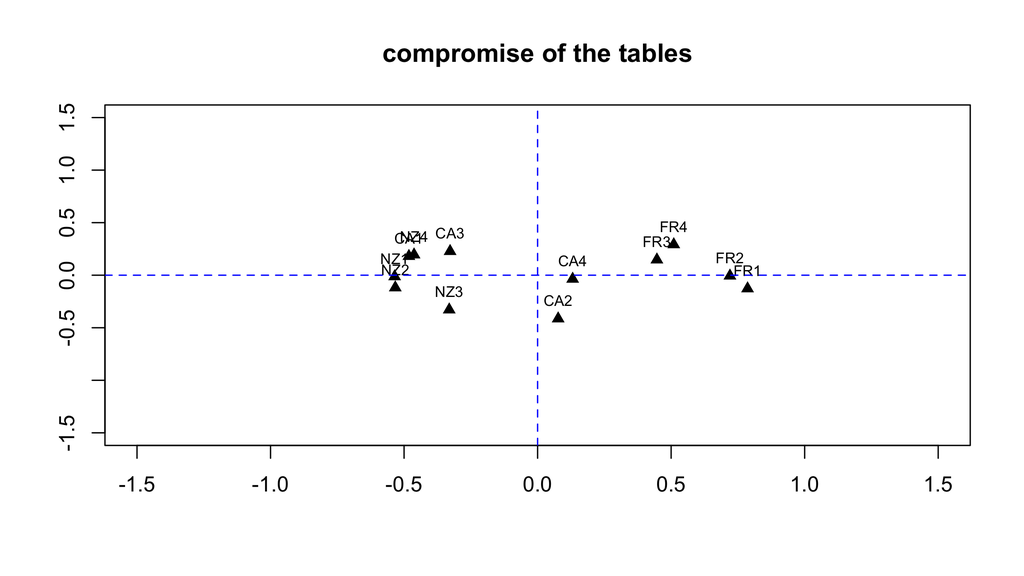

```r
plot.comp(mfa1)
```

### plot.pfs

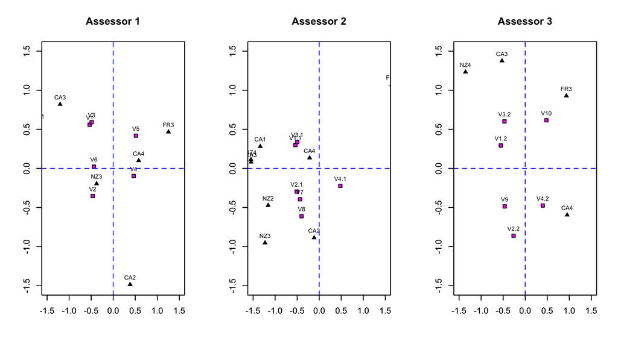

```r
par(mfrow=c(1,1))
plot.pfs(mfa1)
```

### plot.loadings

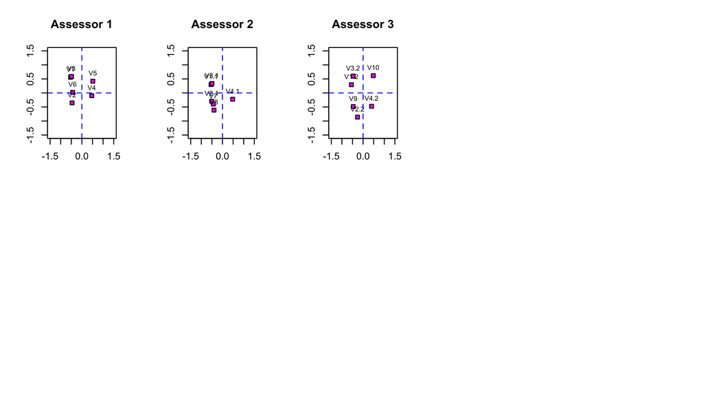

```r
par(mfrow=c(1,1))
plot.loadings(mfa1)
```

### related methods and functions

- **eigentbl**: table summary of eigenvalues (singular values, eigenvalues, cumulative, % inertia, cumulative % inertia)
- **ob2dim**: contribution of an observation to a dimension
- **var2dim**: contribution of a variable to a dimension
- **tbl2dim**: contribution of a table to a dimension
- **RV**: similarity between two tables using the Rv coefficient
- **RVtbl**: similarity between multiple tables using the Rv coefficient

### eigentbl

```r
eigentbl(mfa1)
```

```
     sing_vals eigen eigen_cum perc_inertia perc_cum
[1,]     0.488 0.238     0.238           63       63
[2,]     0.212 0.045     0.283           12       75
[3,]     0.162 0.026     0.309            7       82
[4,]     0.158 0.025     0.334            7       89
[5,]     0.122 0.015     0.349            4       92
[6,]     0.099 0.010     0.359            3       95
```

Note: Table values have subsetted to fit on the slide.

### ob2dim

```r
ob2dim(mfa1)
```

```
      [,1]  [,2]  [,3]  [,4]  [,5]
[1,] 0.100 0.000 0.003 0.018 0.101
[2,] 0.100 0.026 0.171 0.073 0.001
[3,] 0.038 0.200 0.007 0.000 0.132
[4,] 0.075 0.070 0.135 0.020 0.030
[5,] 0.217 0.030 0.037 0.035 0.008
```

Note: Table values have been rounded and subsetted to fit on the slide.

### var2dim

```r
var2dim(mfa1)
```

```
       [,1]  [,2]
 [1,] 0.069 0.075
 [2,] 0.052 0.030
 [3,] 0.058 0.084
 [4,] 0.052 0.002
 [5,] 0.064 0.042
 [6,] 0.046 0.000
 [7,] 0.069 0.021
 [8,] 0.062 0.021
 [9,] 0.059 0.027
[10,] 0.055 0.012
[11,] 0.045 0.037
[12,] 0.038 0.089
[13,] 0.084 0.024
[14,] 0.019 0.204
[15,] 0.061 0.099
[16,] 0.044 0.062
[17,] 0.060 0.065
[18,] 0.064 0.104
```

Note: Table values have been rounded and subsetted to fit on the slide.

### tbl2dim

```r
tbl2dim(mfa1)
```

```
      [,1]  [,2]
[1,] 0.340 0.234
[2,] 0.329 0.208
[3,] 0.330 0.558
```

Note: Table values have been rounded and subsetted to fit on the slide.

### RV

```r
RV(tbl1,tbl2)
```

```
[1] 0.9701797
```

### RVtbl

```r
RVtbl(df,sets=list(2:7,8:13,14:19))
```

```
          [,1]      [,2]      [,3]
[1,] 1.0000000 0.9701797 0.9843314
[2,] 0.9701797 1.0000000 0.9760064
[3,] 0.9843314 0.9760064 1.0000000
```